# This is the title: it contains a colon

## Resumen

Lorem Ipsum comenzó como un latín revuelto y sin sentido derivado del texto de Cicerón del siglo I aC De Finibus Bonorum et Malorum.

Lorem Ipsum comenzó como un latín revuelto y sin sentido derivado del texto de Cicerón del siglo I aC De Finibus Bonorum et Malorum.

**Keywords:** nothing, nothingness,

# 1 Pandoc template in Bootstrap 5

This template has been created to use [Pandoc](https://pandoc.org/) as a parser for Markdown files. The idea is to use it to create static HTML files from [my books](https://github.com/yuki/my-books). This template uses [Bootstrap 5](https://getbootstrap.com/).

# 2 Example of uses

Here there are some examples of how to use this template:

## 2.1 Images

Here few examples of with images.

### 2.1.1 Centered image with caption

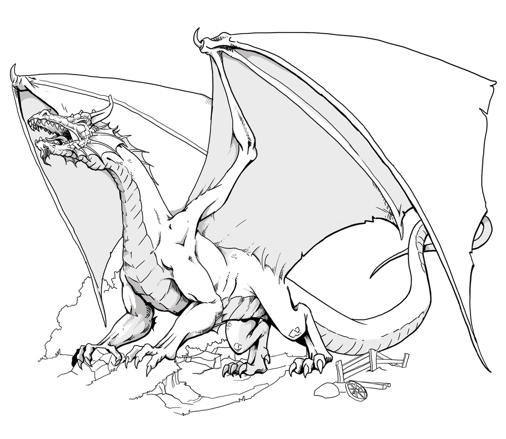

this is a dragon

### 2.1.2 Float image in the left side

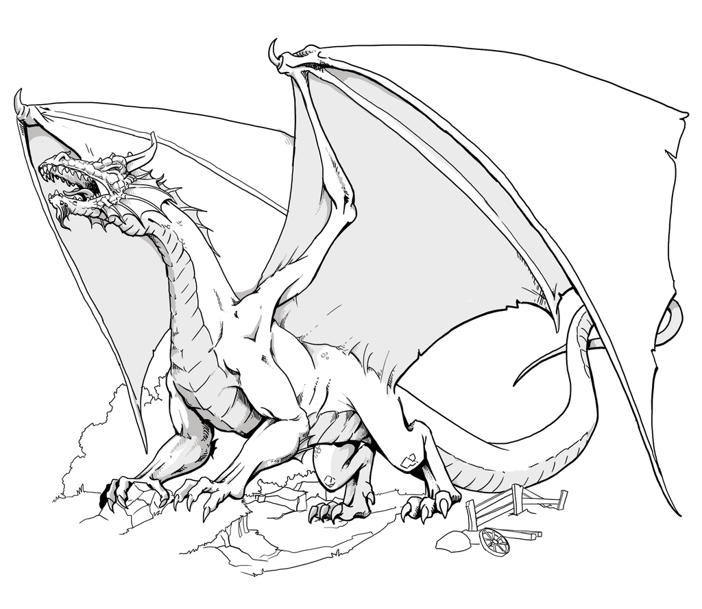

this is a dragon

Lorem Ipsum comenzó como un latín revuelto y sin sentido derivado del texto de Cicerón del siglo I aC De Finibus Bonorum et Malorum. Lorem Ipsum comenzó como un latín revuelto y sin sentido derivado del texto de Cicerón del siglo I aC De Finibus Bonorum et Malorum. Lorem Ipsum comenzó como un latín revuelto y sin sentido derivado del texto de Cicerón del siglo I aC De Finibus Bonorum et Malorum. Lorem Ipsum comenzó como un latín revuelto y sin sentido derivado del texto de Cicerón del siglo I aC De Finibus Bonorum et Malorum.

Lorem Ipsum comenzó como un latín revuelto y sin sentido derivado del texto de Cicerón del siglo I aC De Finibus Bonorum et Malorum. Lorem Ipsum comenzó como un latín revuelto y sin sentido derivado del texto de Cicerón del siglo I aC De Finibus Bonorum et Malorum.

## 2.2 Tables

A normal table:

|  | Col 1 | Col 2 | Col 3 | Col 4 |
| --- | --- | --- | --- | --- |
| Fila 1 | a |  |  |  |
| Fila 2 |  | b |  | a |
| Fila 3 |  |  | c |  |

## 2.3 Custom boxes

Here few custom boxes with code:

```php
<?php
use Illuminate\Database\Migrations\Migration;
use Illuminate\Database\Schema\Blueprint;
use Illuminate\Support\Facades\Schema;

return new class extends Migration {
    public function up(): void {
        Schema::create('users', function (Blueprint $table) {
            $table->id();
            $table->string('name');
            //...
        });
    }
};
```

Another example for console:

```bash
root@1b29e46c10ae:/var/www/html# php artisan make:model Post -crms
```

This is an infobox:

This is an info box!

# 3 Lorem ipsum

```python
print("hello")
```

## 3.1 Pyout

```python
from IPython.display import HTML
HTML("""
<script>
console.log("hello");
</script>
<b>HTML</b>
""")
```

[output not shown]

**Lorem ipsum** dolor sit amet, consectetur adipiscing elit. Nunc luctus bibendum felis dictum sodales.

# 4 Lorem ipsum

**Lorem ipsum** dolor sit amet, consectetur adipiscing elit. Nunc luctus bibendum felis dictum sodales.

```python
print("hello")
```

## 4.1 Pyout

```python
from IPython.display import HTML
HTML("""
<script>
console.log("hello");
</script>
<b>HTML</b>
""")
```

[output not shown]